# Training the Models

Nathan Byers

Sunday, April 12, 2015

This page documents the model training process. For documentation on how the data was prepared, see [this page](http://rpubs.com/NateByers/machLearnDataPrep).

## Preprocessing

First, we library all of the necessary packages and load the training and test sets.

```r
library(kernlab)
library(caret)
library(pROC)
# library the genefilter package (install from bioconductor first if it's not
# installed already)
if(!require(genefilter)){
  source("http://bioconductor.org/biocLite.R")
  biocLite("genefilter")
  library(genefilter)
}
load("../Data/split_data.RData")
ls()
```

```
## [1] "miRNA_pvalue" "test_data"    "train_data"
```

Then we make sure that the stage column in those data frames are factors.

```r
train_data$stage <- as.factor(train_data$stage)
test_data$stage <- as.factor(test_data$stage)
```

We’ll do two kinds of preprocessing:

1. Filter based on the intensity of the miRNA expression and the coefficient of variation, and
2. Filter based on the p-value from the t-test in the [data preparation stage](http://rpubs.com/NateByers/machLearnDataPrep) and then transformation using principal components.

### Preprocessing: Method 1

Here we create a function that filters out miRNAs that do not have at least 20% of the sample expression value at 100 or greater. Then it filters out miRNAs that do not have coefficient of variation (sd/mean) between 0.7 and 10. (https://www.biostars.org/p/86981/)

```r
exprFilterFun <- filterfun(pOverA(p = 0.2, A = 100), cv(a = 0.7, b = 10))
```

Now we filter the training and test data sets.

```r
# make a matrix from the train_data data frame
train_matrix <- train_data[, -c(1:2)]
# transpose the matrix so that rows are miRNAs and columns are samples
train_matrix_t <- t(train_matrix)
# create a logical vector that indicates TRUE for features that meet the
# filter requirments
expr_filter <- genefilter(train_matrix_t, exprFilterFun)
# see how many features are left
sum(expr_filter)
```

```
## [1] 45
```

```r
# subset the training data down to the features that meet the requirements
train_data_filtered <- train_data[, c(TRUE, TRUE, expr_filter)]
# subset test data
test_data_filtered <- test_data[, names(train_data_filtered)]
```

### Preprocessing: Method 2

For this method, we narrow the features down by choosing a p-value threshold, and then using principal component analysis to transform the data into linear combinations of the miRNA expression data.

Here we choose a threshold of 0.1 for the p-values.

```r
sig_rna <- miRNA_pvalue[miRNA_pvalue$pvalue <= .1, "miRNA_id"]
train_data_sig <- data.frame(train_data[, 1:2],
                             train_data[, sig_rna])
test_data_sig <- data.frame(test_data[, 1:2],
                            test_data[, sig_rna])
```

Then we apply PCA to the remaining data set. We’ll choose a threshold of 95% (choose components that account for 95% of the variation in the data).

```r
trans <- preProcess(train_data_sig[, -c(1:2)],
                   method = c("center", "scale", "pca"),
                   thresh = 0.95)
trans
```

```
##
## Call:
## preProcess.default(x = train_data_sig[, -c(1:2)], method =
##  c("center", "scale", "pca"), thresh = 0.95)
##
## Created from 424 samples and 221 variables
## Pre-processing: centered, scaled, principal component signal extraction
##
## PCA needed 117 components to capture 95 percent of the variance
```

117 components will be used

## Splitting

We’ll be using the training samples, which totals 424 observations. To train the parameters for each model, we’ll use two data splitting methods. 5- fold cross validation and 10 fold cross validation.

### 5-fold Cross Validation

Here we set the training control for 5-fold cross validation.

```r
ctrl5f <- trainControl(method = "cv", number = 5,
                      summaryFunction = twoClassSummary,
                      classProbs = TRUE)
```

### 10-fold Cross Validation

And here we set the training control for 10-fold cross validation.

```r
ctrl10f <- trainControl(method = "cv", number = 10,
                      summaryFunction = twoClassSummary,
                      classProbs = TRUE)
```

## Support Vector Machine (SVM)

The first algorithm is the support vector machine.

### SVM/PreProc1/5-foldCV

The first model we’ll train is the support vector machine, using the first preproccessing method and 5-fold cross validation.

First we make a tuning grid that covers a range of sigma and cost values (Kuhn and Johnson 2013)

```r
svmrGrid <- expand.grid(sigma = c(.00007, .00009, .0001, .0002),
                        C = 2^(-3:8))
```

Now we fit the model and report the run time. ROC is used to select the optimal model.

```r
then <- Sys.time()
set.seed(477)
svm_pre1_5cv <- train(stage ~ .,
             data = train_data_filtered[, -1],
             method = "svmRadial",
             tuneGrid = svmrGrid,
             metric = "ROC",
             trControl = ctrl5f)
Sys.time() - then
```

```
## Time difference of 27.81267 secs
```

We predict using the test set and evaluate the performance.

```r
svm_pre1_5cv_pred <- predict(svm_pre1_5cv,
                            newdata = test_data_filtered[, - c(1:2)])
svm_pre1_5cv_prob <- predict(svm_pre1_5cv,
                            newdata = test_data_filtered[, - c(1:2)],
                            type = "prob")

svm_pre1_5cv.df <- data.frame(stage = test_data_filtered$stage,
                             svm_pre1_5cv_pred,
                             early_prob = svm_pre1_5cv_prob$early,
                             late_prob = svm_pre1_5cv_prob$late)

head(svm_pre1_5cv.df)
```

```
##   stage svm_pre1_5cv_pred early_prob late_prob
## 1 early             early  0.7546434 0.2453566
## 2 early              late  0.3258466 0.6741534
## 3 early             early  0.8322489 0.1677511
## 4 early             early  0.7042966 0.2957034
## 5 early             early  0.5331362 0.4668638
## 6 early             early  0.7421521 0.2578479
```

```r
confusionMatrix(data = svm_pre1_5cv.df$svm_pre1_5cv_pred,
                reference = test_data_filtered$stage,
                positive = "late")
```

```
## Confusion Matrix and Statistics
##
##           Reference
## Prediction early late
##      early    57   21
##      late      8   20
##
##                Accuracy : 0.7264
##                  95% CI : (0.6313, 0.8085)
##     No Information Rate : 0.6132
##     P-Value [Acc > NIR] : 0.009744
##
##                   Kappa : 0.3874
##  Mcnemar's Test P-Value : 0.025858
##
##             Sensitivity : 0.4878
##             Specificity : 0.8769
##          Pos Pred Value : 0.7143
##          Neg Pred Value : 0.7308
##              Prevalence : 0.3868
##          Detection Rate : 0.1887
##    Detection Prevalence : 0.2642
##       Balanced Accuracy : 0.6824
##
##        'Positive' Class : late
##
```

```r
svm_pre1_5cv_rocCurve <- roc(response = test_data_filtered$stage,
                predictor = svm_pre1_5cv.df$early_prob,
                ## This function assumes that the second
                ## class is the event of interest, so we
                ## reverse the labels
                levels = rev(levels(test_data_filtered$stage)))

auc(svm_pre1_5cv_rocCurve)
```

```
## Area under the curve: 0.7996
```

```r
ci.roc(svm_pre1_5cv_rocCurve)
```

```
## 95% CI: 0.7136-0.8857 (DeLong)
```

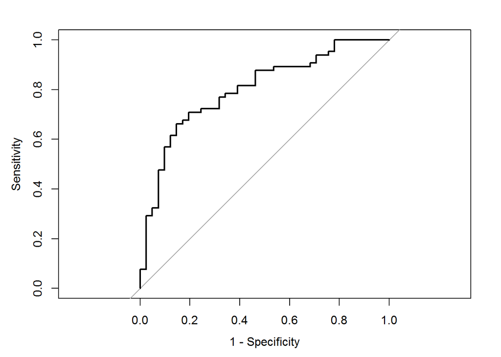

```
##
## Call:
## roc.default(response = test_data_filtered$stage, predictor = svm_pre1_5cv.df$early_prob,     levels = rev(levels(test_data_filtered$stage)))
##
## Data: svm_pre1_5cv.df$early_prob in 41 controls (test_data_filtered$stage late) < 65 cases (test_data_filtered$stage early).
## Area under the curve: 0.7996
```

```r
plot(svm_pre1_5cv_rocCurve, legacy.axes = TRUE)
```

```r
save(svm_pre1_5cv, svm_pre1_5cv_pred, svm_pre1_5cv_prob,
     file = "../Results/svm_pre1_5cv.RData")
```

### SVM/PreProc2/5-foldCV

SVM, preprocessing method 2, and 5 fold cross validation. (The default threshold for “pca” in the `preProc` argument is 95%)

```r
then <- Sys.time()
set.seed(477)
svm_pre2_5cv <- train(stage ~ .,
             data = train_data_sig[, -1],
             method = "svmRadial",
             tuneGrid = svmrGrid,
             preProc = c("center", "scale", "pca"),
             metric = "ROC",
             trControl = ctrl5f)
```

```
## maximum number of iterations reached 3.491983e-05 3.484089e-05maximum number of iterations reached 2.17924e-05 2.174739e-05
```

```r
Sys.time() - then
```

```
## Time difference of 1.239041 mins
```

```r
svm_pre2_5cv_pred <- predict(svm_pre2_5cv,
                            newdata = test_data_sig[, - c(1:2)])
svm_pre2_5cv_prob <- predict(svm_pre2_5cv,
                            newdata = test_data_sig[, - c(1:2)],
                            type = "prob")

svm_pre2_5cv.df <- data.frame(stage = test_data_sig$stage,
                             svm_pre2_5cv_pred,
                             early_prob = svm_pre2_5cv_prob$early,
                             late_prob = svm_pre2_5cv_prob$late)

head(svm_pre2_5cv.df)
```

```
##   stage svm_pre2_5cv_pred early_prob late_prob
## 1 early             early  0.7733647 0.2266353
## 2 early             early  0.5800195 0.4199805
## 3 early             early  0.7451924 0.2548076
## 4 early              late  0.4315871 0.5684129
## 5 early             early  0.6153190 0.3846810
## 6 early             early  0.7932442 0.2067558
```

```r
confusionMatrix(data = svm_pre2_5cv.df$svm_pre2_5cv_pred,
                reference = test_data_sig$stage,
                positive = "late")
```

```
## Confusion Matrix and Statistics
##
##           Reference
## Prediction early late
##      early    58   25
##      late      7   16
##
##                Accuracy : 0.6981
##                  95% CI : (0.6013, 0.7835)
##     No Information Rate : 0.6132
##     P-Value [Acc > NIR] : 0.043386
##
##                   Kappa : 0.3075
##  Mcnemar's Test P-Value : 0.002654
##
##             Sensitivity : 0.3902
##             Specificity : 0.8923
##          Pos Pred Value : 0.6957
##          Neg Pred Value : 0.6988
##              Prevalence : 0.3868
##          Detection Rate : 0.1509
##    Detection Prevalence : 0.2170
##       Balanced Accuracy : 0.6413
##
##        'Positive' Class : late
##
```

```r
svm_pre2_5cv_rocCurve <- roc(response = test_data_sig$stage,
                predictor = svm_pre2_5cv.df$early_prob,
                ## This function assumes that the second
                ## class is the event of interest, so we
                ## reverse the labels
                levels = rev(levels(test_data_sig$stage)))

auc(svm_pre2_5cv_rocCurve)
```

```
## Area under the curve: 0.6604
```

```r
ci.roc(svm_pre2_5cv_rocCurve)
```

```
## 95% CI: 0.5478-0.773 (DeLong)
```

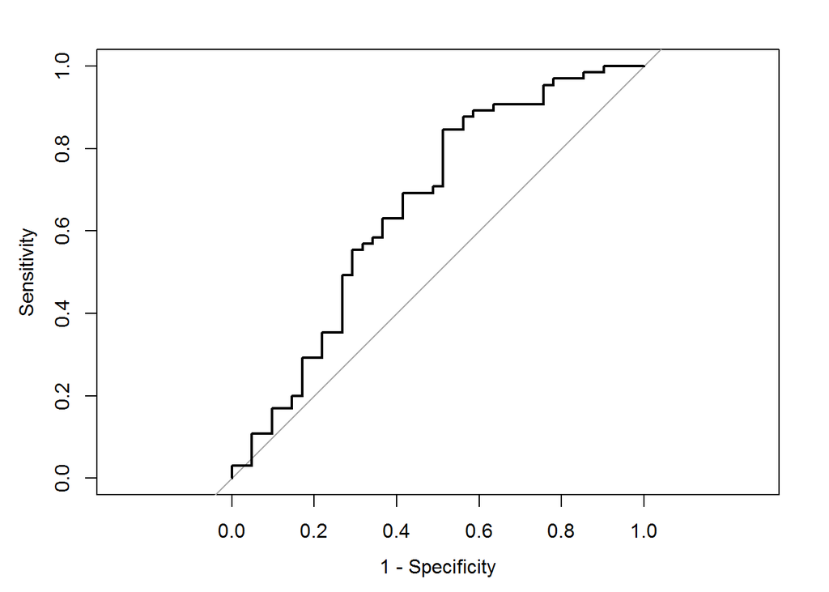

```
##
## Call:
## roc.default(response = test_data_sig$stage, predictor = svm_pre2_5cv.df$early_prob,     levels = rev(levels(test_data_sig$stage)))
##
## Data: svm_pre2_5cv.df$early_prob in 41 controls (test_data_sig$stage late) < 65 cases (test_data_sig$stage early).
## Area under the curve: 0.6604
```

```r
plot(svm_pre2_5cv_rocCurve, legacy.axes = TRUE)
```

```r
save(svm_pre2_5cv, svm_pre2_5cv_pred, svm_pre2_5cv_prob,
     file = "../Results/svm_pre2_5cv.RData")
```

### SVM/PreProc1/10-foldCV

SVM, preproccessing method 1, and 10 fold cross validation.

```r
then <- Sys.time()
set.seed(477)
svm_pre1_10cv <- train(stage ~ .,
             data = train_data_filtered[, -1],
             method = "svmRadial",
             tuneGrid = svmrGrid,
             metric = "ROC",
             trControl = ctrl10f)
Sys.time() - then
```

```
## Time difference of 54.44594 secs
```

We predict using the test set and evaluate the performance.

```r
svm_pre1_10cv_pred <- predict(svm_pre1_10cv,
                            newdata = test_data_filtered[, - c(1:2)])
svm_pre1_10cv_prob <- predict(svm_pre1_10cv,
                            newdata = test_data_filtered[, - c(1:2)],
                            type = "prob")

svm_pre1_10cv.df <- data.frame(stage = test_data_filtered[, "stage"],
                             svm_pre1_10cv_pred,
                             early_prob = svm_pre1_10cv_prob$early,
                             late_prob = svm_pre1_10cv_prob$late)

head(svm_pre1_10cv.df)
```

```
##   stage svm_pre1_10cv_pred early_prob late_prob
## 1 early              early  0.8349623 0.1650377
## 2 early               late  0.4175511 0.5824489
## 3 early              early  0.8705517 0.1294483
## 4 early              early  0.7254903 0.2745097
## 5 early              early  0.6109064 0.3890936
## 6 early              early  0.7569519 0.2430481
```

```r
confusionMatrix(data = svm_pre1_10cv.df$svm_pre1_10cv_pred,
                reference = test_data_filtered[, "stage"],
                positive = "late")
```

```
## Confusion Matrix and Statistics
##
##           Reference
## Prediction early late
##      early    57   25
##      late      8   16
##
##                Accuracy : 0.6887
##                  95% CI : (0.5914, 0.7751)
##     No Information Rate : 0.6132
##     P-Value [Acc > NIR] : 0.065898
##
##                   Kappa : 0.2893
##  Mcnemar's Test P-Value : 0.005349
##
##             Sensitivity : 0.3902
##             Specificity : 0.8769
##          Pos Pred Value : 0.6667
##          Neg Pred Value : 0.6951
##              Prevalence : 0.3868
##          Detection Rate : 0.1509
##    Detection Prevalence : 0.2264
##       Balanced Accuracy : 0.6336
##
##        'Positive' Class : late
##
```

```r
svm_pre1_10cv_rocCurve <- roc(response = test_data_filtered[, "stage"],
                predictor = svm_pre1_10cv.df$early_prob,
                ## This function assumes that the second
                ## class is the event of interest, so we
                ## reverse the labels
                levels = rev(levels(test_data_filtered[, "stage"])))

auc(svm_pre1_10cv_rocCurve)
```

```
## Area under the curve: 0.7644
```

```r
ci.roc(svm_pre1_10cv_rocCurve)
```

```
## 95% CI: 0.6682-0.8605 (DeLong)
```

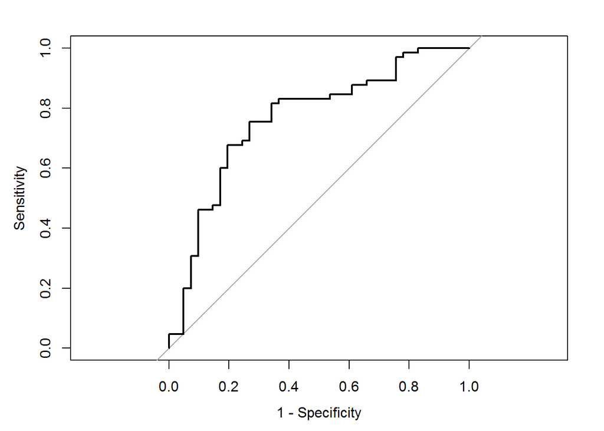

```
##
## Call:
## roc.default(response = test_data_filtered[, "stage"], predictor = svm_pre1_10cv.df$early_prob,     levels = rev(levels(test_data_filtered[, "stage"])))
##
## Data: svm_pre1_10cv.df$early_prob in 41 controls (test_data_filtered[, "stage"] late) < 65 cases (test_data_filtered[, "stage"] early).
## Area under the curve: 0.7644
```

```r
plot(svm_pre1_10cv_rocCurve, legacy.axes = TRUE)
```

```r
save(svm_pre1_10cv, svm_pre1_10cv_pred, svm_pre1_10cv_prob,
     file = "../Results/svm_pre1_10cv.RData")
```

### SVM/PreProc2/10-foldCV

SVM, preprocessing method 2, and 10-fold cross validation.

```r
then <- Sys.time()
set.seed(477)
svm_pre2_10cv <- train(stage ~ .,
             data = train_data_sig[, -1],
             method = "svmRadial",
             tuneGrid = svmrGrid,
             preProc = c("center", "scale", "pca"),
             metric = "ROC",
             trControl = ctrl10f)
Sys.time() - then
```

```
## Time difference of 2.62259 mins
```

```r
svm_pre2_10cv_pred <- predict(svm_pre2_10cv,
                            newdata = test_data_sig[, - c(1:2)])
svm_pre2_10cv_prob <- predict(svm_pre2_10cv,
                            newdata = test_data_sig[, - c(1:2)],
                            type = "prob")

svm_pre2_10cv.df <- data.frame(stage = test_data_sig[, "stage"],
                             svm_pre2_10cv_pred,
                             early_prob = svm_pre2_10cv_prob$early,
                             late_prob = svm_pre2_10cv_prob$late)

head(svm_pre2_10cv.df)
```

```
##   stage svm_pre2_10cv_pred early_prob late_prob
## 1 early              early  0.8124083 0.1875917
## 2 early               late  0.4760781 0.5239219
## 3 early              early  0.7788731 0.2211269
## 4 early               late  0.3690614 0.6309386
## 5 early              early  0.5924416 0.4075584
## 6 early              early  0.7155900 0.2844100
```

```r
confusionMatrix(data = svm_pre2_10cv.df$svm_pre2_10cv_pred,
                reference = test_data_sig[, "stage"],
                positive = "late")
```

```
## Confusion Matrix and Statistics
##
##           Reference
## Prediction early late
##      early    55   24
##      late     10   17
##
##                Accuracy : 0.6792
##                  95% CI : (0.5816, 0.7666)
##     No Information Rate : 0.6132
##     P-Value [Acc > NIR] : 0.09639
##
##                   Kappa : 0.2783
##  Mcnemar's Test P-Value : 0.02578
##
##             Sensitivity : 0.4146
##             Specificity : 0.8462
##          Pos Pred Value : 0.6296
##          Neg Pred Value : 0.6962
##              Prevalence : 0.3868
##          Detection Rate : 0.1604
##    Detection Prevalence : 0.2547
##       Balanced Accuracy : 0.6304
##
##        'Positive' Class : late
##
```

```r
svm_pre2_10cv_rocCurve <- roc(response = test_data_sig[, "stage"],
                predictor = svm_pre2_10cv.df$early_prob,
                ## This function assumes that the second
                ## class is the event of interest, so we
                ## reverse the labels
                levels = rev(levels(test_data_sig[, "stage"])))

auc(svm_pre2_10cv_rocCurve)
```

```
## Area under the curve: 0.7081
```

```r
ci.roc(svm_pre2_10cv_rocCurve)
```

```
## 95% CI: 0.6066-0.8096 (DeLong)
```

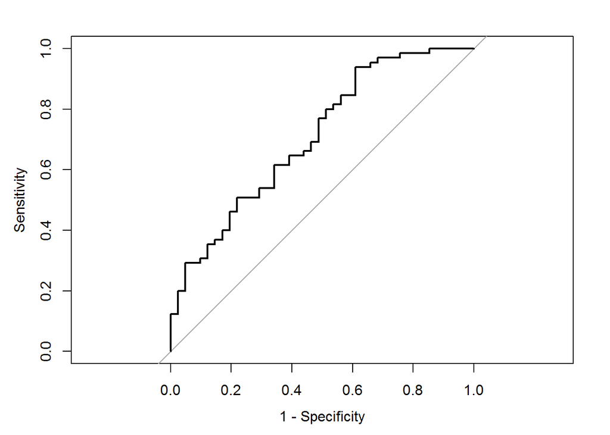

```
##
## Call:
## roc.default(response = test_data_sig[, "stage"], predictor = svm_pre2_10cv.df$early_prob,     levels = rev(levels(test_data_sig[, "stage"])))
##
## Data: svm_pre2_10cv.df$early_prob in 41 controls (test_data_sig[, "stage"] late) < 65 cases (test_data_sig[, "stage"] early).
## Area under the curve: 0.7081
```

```r
plot(svm_pre2_10cv_rocCurve, legacy.axes = TRUE)
```

```r
save(svm_pre2_10cv, svm_pre2_10cv_pred, svm_pre2_10cv_prob,
     file = "../Results/svm_pre2_10cv.RData")
```

## Random Forest (RF)

The second algorithm is random forest.

### RF/PreProc1/5-foldCV

Random forest, preprocessing method 1, 5 fold cross validation.

For random forest, we tune the mtry parameter using 5 values evenly spaced from 2 to p, where p = # of predictors. We also use an ensemble of 1000 trees (pg. 387, Kuhn and Johnson 2013)

```r
p <- ncol(train_data_filtered) - 2
spaced.values <- round(seq(2, p, length.out = 7))
mtryValues <- spaced.values[2:6]

then <- Sys.time()
set.seed(477)
rf_pre1_5cv <- train(x = train_data_filtered[, -c(1:2)],
               y = train_data_filtered$stage,
               method = "rf",
               ntree = 1000,
               tuneGrid = data.frame(mtry = mtryValues),
               importance = TRUE,
               metric = "ROC",
               trControl = ctrl5f)
Sys.time() - then
```

```
## Time difference of 38.28141 secs
```

```r
rf_pre1_5cv_pred <- predict(rf_pre1_5cv,
                            newdata = test_data_filtered[, - c(1:2)])
rf_pre1_5cv_prob <- predict(rf_pre1_5cv,
                            newdata = test_data_filtered[, - c(1:2)],
                            type = "prob")

rf_pre1_5cv.df <- data.frame(stage = test_data_filtered$stage,
                             rf_pre1_5cv_pred,
                             early_prob = rf_pre1_5cv_prob$early,
                             late_prob = rf_pre1_5cv_prob$late)

head(rf_pre1_5cv.df)
```

```
##   stage rf_pre1_5cv_pred early_prob late_prob
## 1 early            early      0.671     0.329
## 2 early             late      0.252     0.748
## 3 early            early      0.926     0.074
## 4 early            early      0.673     0.327
## 5 early            early      0.635     0.365
## 6 early            early      0.862     0.138
```

```r
confusionMatrix(data = rf_pre1_5cv.df$rf_pre1_5cv_pred,
                reference = test_data_filtered$stage,
                positive = "late")
```

```
## Confusion Matrix and Statistics
##
##           Reference
## Prediction early late
##      early    58   21
##      late      7   20
##
##                Accuracy : 0.7358
##                  95% CI : (0.6413, 0.8168)
##     No Information Rate : 0.6132
##     P-Value [Acc > NIR] : 0.005444
##
##                   Kappa : 0.4057
##  Mcnemar's Test P-Value : 0.014019
##
##             Sensitivity : 0.4878
##             Specificity : 0.8923
##          Pos Pred Value : 0.7407
##          Neg Pred Value : 0.7342
##              Prevalence : 0.3868
##          Detection Rate : 0.1887
##    Detection Prevalence : 0.2547
##       Balanced Accuracy : 0.6901
##
##        'Positive' Class : late
##
```

```r
rf_pre1_5cv_rocCurve <- roc(response = test_data_filtered$stage,
                predictor = rf_pre1_5cv.df$early_prob,
                ## This function assumes that the second
                ## class is the event of interest, so we
                ## reverse the labels
                levels = rev(levels(test_data_filtered$stage)))

auc(rf_pre1_5cv_rocCurve)
```

```
## Area under the curve: 0.831
```

```r
ci.roc(rf_pre1_5cv_rocCurve)
```

```
## 95% CI: 0.7499-0.912 (DeLong)
```

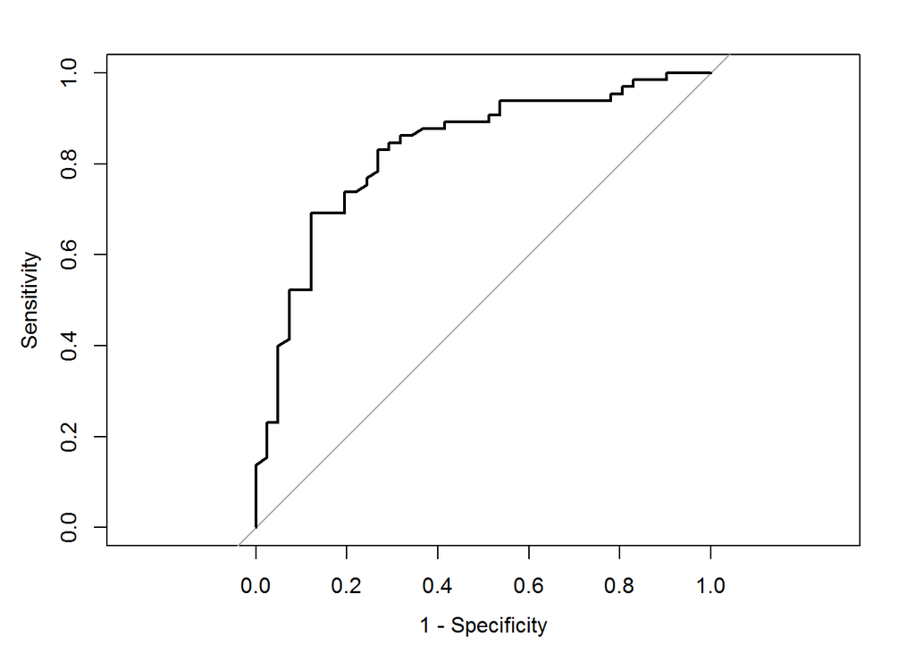

```
##
## Call:
## roc.default(response = test_data_filtered$stage, predictor = rf_pre1_5cv.df$early_prob,     levels = rev(levels(test_data_filtered$stage)))
##
## Data: rf_pre1_5cv.df$early_prob in 41 controls (test_data_filtered$stage late) < 65 cases (test_data_filtered$stage early).
## Area under the curve: 0.831
```

```r
plot(rf_pre1_5cv_rocCurve, legacy.axes = TRUE)
```

```r
save(rf_pre1_5cv, rf_pre1_5cv_pred, rf_pre1_5cv_prob,
     file = "../Results/rf_pre1_5cv.RData")
```

### RF/PreProc2/5-foldCV

Random forest, preprocessing method 2, 5 fold cross validation.

```r
then <- Sys.time()
set.seed(477)
rf_pre2_5cv <- train(x = train_data_sig[, -c(1:2)],
               y = train_data_sig$stage,
               method = "rf",
               ntree = 1000,
               tuneGrid = data.frame(mtry = mtryValues),
               preProc = c("center", "scale", "pca"),
               importance = TRUE,
               metric = "ROC",
               trControl = ctrl5f)
Sys.time() - then
```

```
## Time difference of 1.135894 mins
```

```r
rf_pre2_5cv_pred <- predict(rf_pre2_5cv,
                            newdata = test_data_sig[, - c(1:2)])
rf_pre2_5cv_prob <- predict(rf_pre2_5cv,
                            newdata = test_data_sig[, - c(1:2)],
                            type = "prob")

rf_pre2_5cv.df <- data.frame(stage = test_data_sig$stage,
                             rf_pre2_5cv_pred,
                             early_prob = rf_pre2_5cv_prob$early,
                             late_prob = rf_pre2_5cv_prob$late)

head(rf_pre2_5cv.df)
```

```
##   stage rf_pre2_5cv_pred early_prob late_prob
## 1 early            early      0.757     0.243
## 2 early             late      0.493     0.507
## 3 early            early      0.868     0.132
## 4 early            early      0.542     0.458
## 5 early            early      0.563     0.437
## 6 early            early      0.685     0.315
```

```r
confusionMatrix(data = rf_pre2_5cv.df$rf_pre2_5cv_pred,
                reference = test_data_sig$stage,
                positive = "late")
```

```
## Confusion Matrix and Statistics
##
##           Reference
## Prediction early late
##      early    57   19
##      late      8   22
##
##                Accuracy : 0.7453
##                  95% CI : (0.6514, 0.8249)
##     No Information Rate : 0.6132
##     P-Value [Acc > NIR] : 0.002909
##
##                   Kappa : 0.4351
##  Mcnemar's Test P-Value : 0.054292
##
##             Sensitivity : 0.5366
##             Specificity : 0.8769
##          Pos Pred Value : 0.7333
##          Neg Pred Value : 0.7500
##              Prevalence : 0.3868
##          Detection Rate : 0.2075
##    Detection Prevalence : 0.2830
##       Balanced Accuracy : 0.7068
##
##        'Positive' Class : late
##
```

```r
rf_pre2_5cv_rocCurve <- roc(response = test_data_sig$stage,
                predictor = rf_pre2_5cv.df$early_prob,
                ## This function assumes that the second
                ## class is the event of interest, so we
                ## reverse the labels
                levels = rev(levels(test_data_sig$stage)))

auc(rf_pre2_5cv_rocCurve)
```

```
## Area under the curve: 0.7884
```

```r
ci.roc(rf_pre2_5cv_rocCurve)
```

```
## 95% CI: 0.6979-0.8788 (DeLong)
```

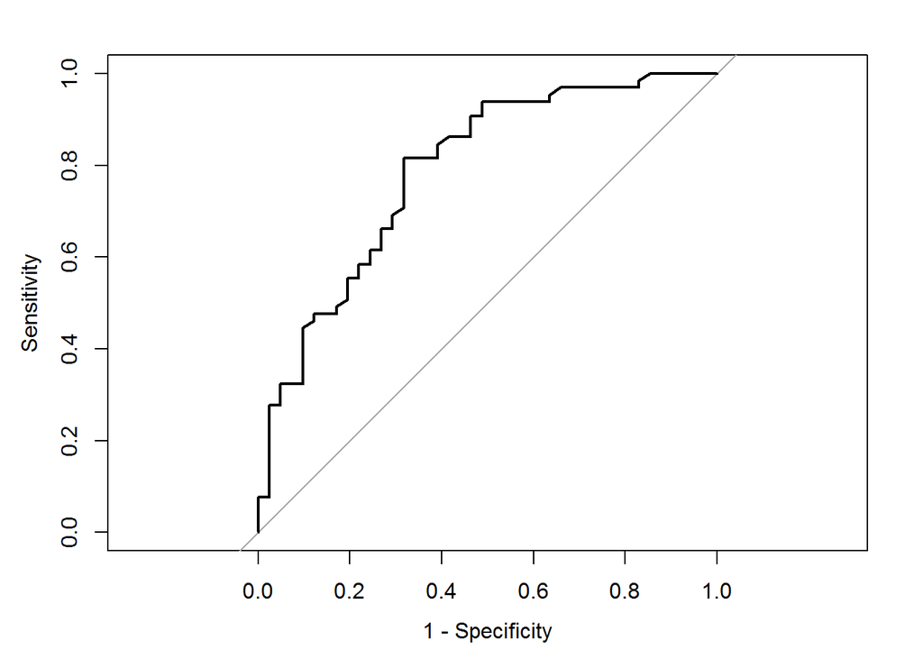

```
##
## Call:
## roc.default(response = test_data_sig$stage, predictor = rf_pre2_5cv.df$early_prob,     levels = rev(levels(test_data_sig$stage)))
##
## Data: rf_pre2_5cv.df$early_prob in 41 controls (test_data_sig$stage late) < 65 cases (test_data_sig$stage early).
## Area under the curve: 0.7884
```

```r
plot(rf_pre2_5cv_rocCurve, legacy.axes = TRUE)
```

```r
save(rf_pre2_5cv, rf_pre2_5cv_pred, rf_pre2_5cv_prob,
     file = "../Results/rf_pre2_5cv.RData")
```

### RF/PreProc1/10-foldCV

Random forest, preprocessing method 1, 10 fold cross validataion.

```r
then <- Sys.time()
set.seed(477)
rf_pre1_10cv <- train(x = train_data_filtered[, -c(1:2)],
               y = train_data_filtered[, "stage"],
               method = "rf",
               ntree = 1000,
               tuneGrid = data.frame(mtry = mtryValues),
               importance = TRUE,
               metric = "ROC",
               trControl = ctrl10f)
Sys.time() - then
```

```
## Time difference of 1.410013 mins
```

```r
rf_pre1_10cv_pred <- predict(rf_pre1_10cv,
                            newdata = test_data_filtered[, - c(1:2)])
rf_pre1_10cv_prob <- predict(rf_pre1_10cv,
                            newdata = test_data_filtered[, - c(1:2)],
                            type = "prob")

rf_pre1_10cv.df <- data.frame(stage = test_data_filtered[, "stage"],
                             rf_pre1_10cv_pred,
                             early_prob = rf_pre1_10cv_prob$early,
                             late_prob = rf_pre1_10cv_prob$late)

head(rf_pre1_10cv.df)
```

```
##   stage rf_pre1_10cv_pred early_prob late_prob
## 1 early             early      0.666     0.334
## 2 early              late      0.259     0.741
## 3 early             early      0.941     0.059
## 4 early             early      0.680     0.320
## 5 early             early      0.582     0.418
## 6 early             early      0.855     0.145
```

```r
confusionMatrix(data = rf_pre1_10cv.df$rf_pre1_10cv_pred,
                reference = test_data_filtered[, "stage"],
                positive = "late")
```

```
## Confusion Matrix and Statistics
##
##           Reference
## Prediction early late
##      early    58   20
##      late      7   21
##
##                Accuracy : 0.7453
##                  95% CI : (0.6514, 0.8249)
##     No Information Rate : 0.6132
##     P-Value [Acc > NIR] : 0.002909
##
##                   Kappa : 0.4297
##  Mcnemar's Test P-Value : 0.020921
##
##             Sensitivity : 0.5122
##             Specificity : 0.8923
##          Pos Pred Value : 0.7500
##          Neg Pred Value : 0.7436
##              Prevalence : 0.3868
##          Detection Rate : 0.1981
##    Detection Prevalence : 0.2642
##       Balanced Accuracy : 0.7023
##
##        'Positive' Class : late
##
```

```r
rf_pre1_10cv_rocCurve <- roc(response = test_data_filtered[, "stage"],
                predictor = rf_pre1_10cv.df$early_prob,
                ## This function assumes that the second
                ## class is the event of interest, so we
                ## reverse the labels
                levels = rev(levels(test_data_filtered[, "stage"])))

auc(rf_pre1_10cv_rocCurve)
```

```
## Area under the curve: 0.821
```

```r
ci.roc(rf_pre1_10cv_rocCurve)
```

```
## 95% CI: 0.737-0.905 (DeLong)
```

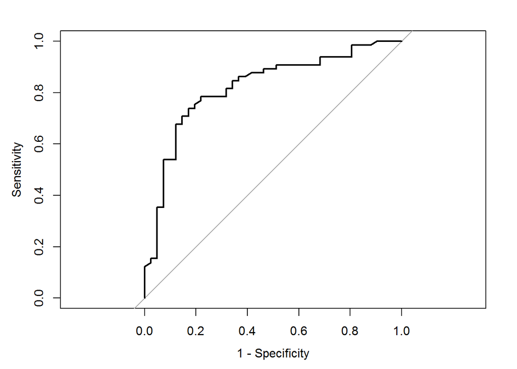

```
##
## Call:
## roc.default(response = test_data_filtered[, "stage"], predictor = rf_pre1_10cv.df$early_prob,     levels = rev(levels(test_data_filtered[, "stage"])))
##
## Data: rf_pre1_10cv.df$early_prob in 41 controls (test_data_filtered[, "stage"] late) < 65 cases (test_data_filtered[, "stage"] early).
## Area under the curve: 0.821
```

```r
plot(rf_pre1_10cv_rocCurve, legacy.axes = TRUE)
```

```r
save(rf_pre1_10cv, rf_pre1_10cv_pred, rf_pre1_10cv_prob,
     file = "../Results/rf_pre1_10cv.RData")
```

### RF/PreProc2/10-foldCV

Random forest, preprocessing method, 10 fold cross validation

```r
then <- Sys.time()
set.seed(477)
rf_pre2_10cv <- train(x = train_data_sig[, -c(1:2)],
               y = train_data_sig[, "stage"],
               method = "rf",
               ntree = 1000,
               tuneGrid = data.frame(mtry = mtryValues),
               preProc = c("center", "scale", "pca"),
               importance = TRUE,
               metric = "ROC",
               trControl = ctrl10f)
Sys.time() - then
```

```
## Time difference of 2.616941 mins
```

```r
rf_pre2_10cv_pred <- predict(rf_pre2_10cv,
                            newdata = test_data_sig[, - c(1:2)])
rf_pre2_10cv_prob <- predict(rf_pre2_10cv,
                            newdata = test_data_sig[, - c(1:2)],
                            type = "prob")

rf_pre2_10cv.df <- data.frame(stage = test_data_sig[, "stage"],
                             rf_pre2_10cv_pred,
                             early_prob = rf_pre2_10cv_prob$early,
                             late_prob = rf_pre2_10cv_prob$late)

head(rf_pre2_10cv.df)
```

```
##   stage rf_pre2_10cv_pred early_prob late_prob
## 1 early             early      0.750     0.250
## 2 early              late      0.488     0.512
## 3 early             early      0.816     0.184
## 4 early             early      0.543     0.457
## 5 early             early      0.549     0.451
## 6 early             early      0.644     0.356
```

```r
confusionMatrix(data = rf_pre2_10cv.df$rf_pre2_10cv_pred,
                reference = test_data_sig[, "stage"],
                positive = "late")
```

```
## Confusion Matrix and Statistics
##
##           Reference
## Prediction early late
##      early    59   21
##      late      6   20
##
##                Accuracy : 0.7453
##                  95% CI : (0.6514, 0.8249)
##     No Information Rate : 0.6132
##     P-Value [Acc > NIR] : 0.002909
##
##                   Kappa : 0.4241
##  Mcnemar's Test P-Value : 0.007054
##
##             Sensitivity : 0.4878
##             Specificity : 0.9077
##          Pos Pred Value : 0.7692
##          Neg Pred Value : 0.7375
##              Prevalence : 0.3868
##          Detection Rate : 0.1887
##    Detection Prevalence : 0.2453
##       Balanced Accuracy : 0.6977
##
##        'Positive' Class : late
##
```

```r
rf_pre2_10cv_rocCurve <- roc(response = test_data_sig[, "stage"],
                predictor = rf_pre2_10cv.df$early_prob,
                ## This function assumes that the second
                ## class is the event of interest, so we
                ## reverse the labels
                levels = rev(levels(test_data_sig[, "stage"])))

auc(rf_pre2_10cv_rocCurve)
```

```
## Area under the curve: 0.7767
```

```r
ci.roc(rf_pre2_10cv_rocCurve)
```

```
## 95% CI: 0.6849-0.8686 (DeLong)
```

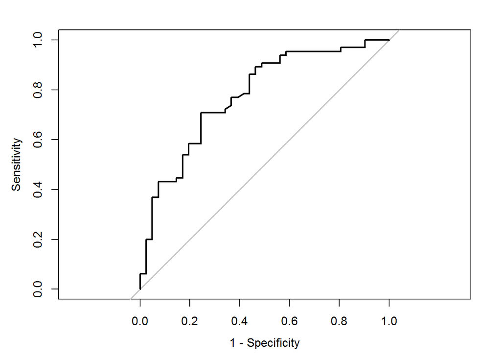

```
##
## Call:
## roc.default(response = test_data_sig[, "stage"], predictor = rf_pre2_10cv.df$early_prob,     levels = rev(levels(test_data_sig[, "stage"])))
##
## Data: rf_pre2_10cv.df$early_prob in 41 controls (test_data_sig[, "stage"] late) < 65 cases (test_data_sig[, "stage"] early).
## Area under the curve: 0.7767
```

```r
plot(rf_pre2_10cv_rocCurve, legacy.axes = TRUE)
```

```r
save(rf_pre2_10cv, rf_pre2_10cv_pred, rf_pre2_10cv_prob,
     file = "../Results/rf_pre2_10cv.RData")
```

## Naive Bayes (NB)

The last algorithm is naive Bayes.

### NB/PreProc1/5-foldCV

Naive Bayes, preprocessing method 1, 5 fold cross validation.

```r
then <- Sys.time()
set.seed(477)
nb_pre1_5cv <- train(x = train_data_filtered[, -c(1:2)],
               y = train_data_filtered$stage,
               method = "nb",
               ntree = 1000,
               tuneGrid = data.frame(usekernel = c(TRUE, FALSE), fL = 2),
               importance = TRUE,
               metric = "ROC",
               trControl = ctrl5f)
Sys.time() - then
```

```
## Time difference of 6.616614 secs
```

```r
nb_pre1_5cv_pred <- predict(nb_pre1_5cv,
                            newdata = test_data_filtered[, - c(1:2)])
nb_pre1_5cv_prob <- predict(nb_pre1_5cv,
                            newdata = test_data_filtered[, - c(1:2)],
                            type = "prob")

nb_pre1_5cv.df <- data.frame(stage = test_data_filtered$stage,
                             nb_pre1_5cv_pred,
                             early_prob = nb_pre1_5cv_prob$early,
                             late_prob = nb_pre1_5cv_prob$late)

head(nb_pre1_5cv.df)
```

```
##   stage nb_pre1_5cv_pred   early_prob    late_prob
## 1 early            early 9.749844e-01 2.501558e-02
## 2 early             late 1.134862e-13 1.000000e+00
## 3 early            early 1.000000e+00 6.178386e-09
## 4 early             late 7.773875e-27 1.000000e+00
## 5 early            early 1.000000e+00 6.718722e-13
## 6 early            early 1.000000e+00 1.464735e-19
```

```r
confusionMatrix(data = nb_pre1_5cv.df$nb_pre1_5cv_pred,
                reference = test_data_filtered$stage,
                positive = "late")
```

```
## Confusion Matrix and Statistics
##
##           Reference
## Prediction early late
##      early    48   21
##      late     17   20
##
##                Accuracy : 0.6415
##                  95% CI : (0.5426, 0.7323)
##     No Information Rate : 0.6132
##     P-Value [Acc > NIR] : 0.3112
##
##                   Kappa : 0.2304
##  Mcnemar's Test P-Value : 0.6265
##
##             Sensitivity : 0.4878
##             Specificity : 0.7385
##          Pos Pred Value : 0.5405
##          Neg Pred Value : 0.6957
##              Prevalence : 0.3868
##          Detection Rate : 0.1887
##    Detection Prevalence : 0.3491
##       Balanced Accuracy : 0.6131
##
##        'Positive' Class : late
##
```

```r
nb_pre1_5cv_rocCurve <- roc(response = test_data_filtered$stage,
                predictor = nb_pre1_5cv.df$early_prob,
                ## This function assumes that the second
                ## class is the event of interest, so we
                ## reverse the labels
                levels = rev(levels(test_data_filtered$stage)))

auc(nb_pre1_5cv_rocCurve)
```

```
## Area under the curve: 0.672
```

```r
ci.roc(nb_pre1_5cv_rocCurve)
```

```
## 95% CI: 0.5642-0.7798 (DeLong)
```

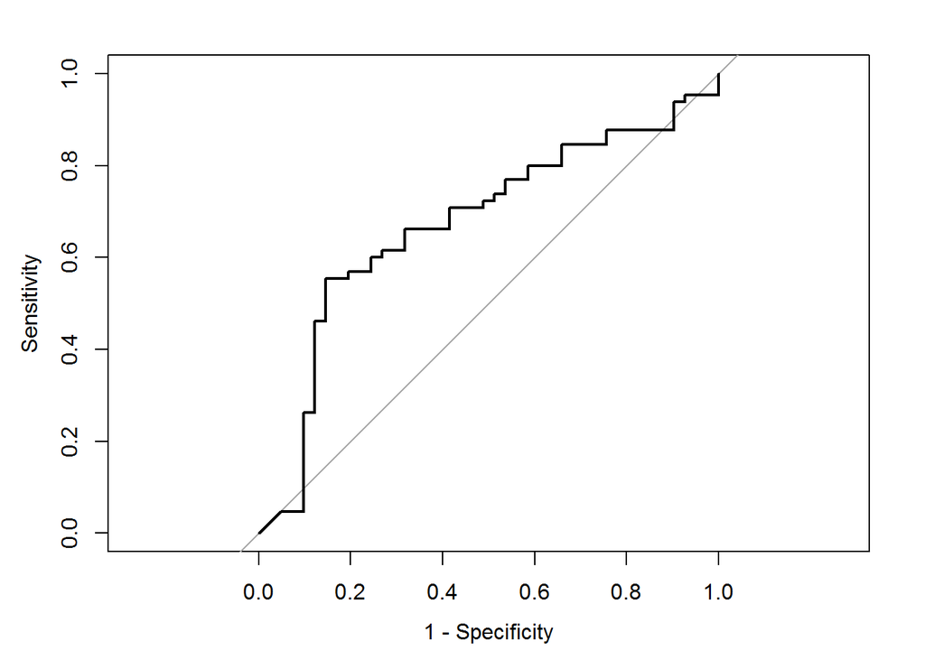

```
##
## Call:
## roc.default(response = test_data_filtered$stage, predictor = nb_pre1_5cv.df$early_prob,     levels = rev(levels(test_data_filtered$stage)))
##
## Data: nb_pre1_5cv.df$early_prob in 41 controls (test_data_filtered$stage late) < 65 cases (test_data_filtered$stage early).
## Area under the curve: 0.672
```

```r
plot(nb_pre1_5cv_rocCurve, legacy.axes = TRUE)
```

```r
save(nb_pre1_5cv, nb_pre1_5cv_pred, nb_pre1_5cv_prob,
     file = "../Results/nb_pre1_5cv.RData")
```

### NB/PreProc2/5-foldCV

Naive Bayes, preprocessing method 2, 5 fold cross validation.

```r
then <- Sys.time()
set.seed(477)
nb_pre2_5cv <- train(x = train_data_sig[, -c(1:2)],
               y = train_data_sig$stage,
               method = "nb",
               ntree = 1000,
               tuneGrid = data.frame(usekernel = c(TRUE, FALSE), fL = 2),
               preProc = c("center", "scale", "pca"),
               importance = TRUE,
               metric = "ROC",
               trControl = ctrl5f)
Sys.time() - then
```

```
## Time difference of 16.84182 secs
```

```r
nb_pre2_5cv_pred <- predict(nb_pre2_5cv,
                            newdata = test_data_sig[, - c(1:2)])
nb_pre2_5cv_prob <- predict(nb_pre2_5cv,
                            newdata = test_data_sig[, - c(1:2)],
                            type = "prob")

nb_pre2_5cv.df <- data.frame(stage = test_data_sig$stage,
                             nb_pre2_5cv_pred,
                             early_prob = nb_pre2_5cv_prob$early,
                             late_prob = nb_pre2_5cv_prob$late)

head(nb_pre2_5cv.df)
```

```
##   stage nb_pre2_5cv_pred   early_prob   late_prob
## 1 early            early 9.989010e-01 0.001098964
## 2 early             late 4.247094e-01 0.575290621
## 3 early            early 9.975956e-01 0.002404399
## 4 early             late 5.295538e-05 0.999947045
## 5 early             late 4.391418e-01 0.560858178
## 6 early            early 9.620655e-01 0.037934535
```

```r
confusionMatrix(data = nb_pre2_5cv.df$nb_pre2_5cv_pred,
                reference = test_data_sig$stage,
                positive = "late")
```

```
## Confusion Matrix and Statistics
##
##           Reference
## Prediction early late
##      early    48   23
##      late     17   18
##
##                Accuracy : 0.6226
##                  95% CI : (0.5233, 0.715)
##     No Information Rate : 0.6132
##     P-Value [Acc > NIR] : 0.4633
##
##                   Kappa : 0.1824
##  Mcnemar's Test P-Value : 0.4292
##
##             Sensitivity : 0.4390
##             Specificity : 0.7385
##          Pos Pred Value : 0.5143
##          Neg Pred Value : 0.6761
##              Prevalence : 0.3868
##          Detection Rate : 0.1698
##    Detection Prevalence : 0.3302
##       Balanced Accuracy : 0.5887
##
##        'Positive' Class : late
##
```

```r
nb_pre2_5cv_rocCurve <- roc(response = test_data_sig$stage,
                predictor = nb_pre2_5cv.df$early_prob,
                ## This function assumes that the second
                ## class is the event of interest, so we
                ## reverse the labels
                levels = rev(levels(test_data_sig$stage)))

auc(nb_pre2_5cv_rocCurve)
```

```
## Area under the curve: 0.6484
```

```r
ci.roc(nb_pre2_5cv_rocCurve)
```

```
## 95% CI: 0.542-0.7549 (DeLong)
```

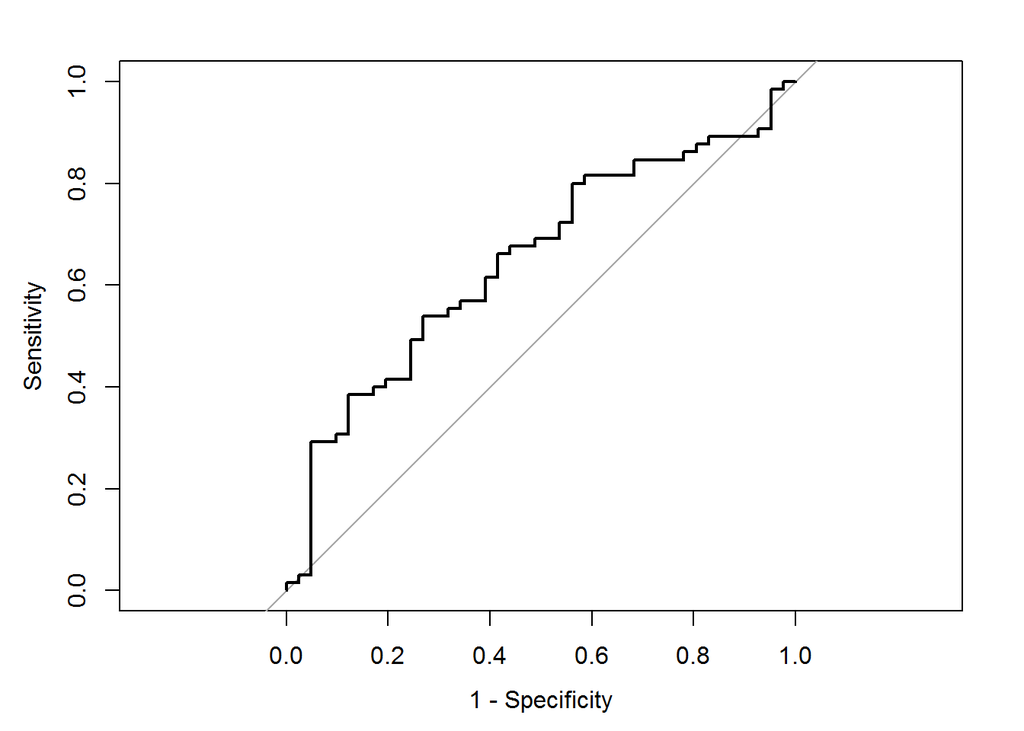

```
##
## Call:
## roc.default(response = test_data_sig$stage, predictor = nb_pre2_5cv.df$early_prob,     levels = rev(levels(test_data_sig$stage)))
##
## Data: nb_pre2_5cv.df$early_prob in 41 controls (test_data_sig$stage late) < 65 cases (test_data_sig$stage early).
## Area under the curve: 0.6484
```

```r
plot(nb_pre2_5cv_rocCurve, legacy.axes = TRUE)
```

```r
save(nb_pre2_5cv, nb_pre2_5cv_pred, nb_pre2_5cv_prob,
     file = "../Results/nb_pre2_5cv.RData")
```

### NB/PreProc1/10-foldCV

Naive Bayes, preprocessing method 1, 10 fold cross validation.

```r
then <- Sys.time()
set.seed(477)
nb_pre1_10cv <- train(x = train_data_filtered[, -c(1:2)],
               y = train_data_filtered[, "stage"],
               method = "nb",
               ntree = 1000,
               tuneGrid = data.frame(usekernel = c(TRUE, FALSE), fL = 2),
               importance = TRUE,
               metric = "ROC",
               trControl = ctrl10f)
Sys.time() - then
```

```
## Time difference of 7.104017 secs
```

```r
nb_pre1_10cv_pred <- predict(nb_pre1_10cv,
                            newdata = test_data_filtered[, - c(1:2)])
nb_pre1_10cv_prob <- predict(nb_pre1_10cv,
                            newdata = test_data_filtered[, - c(1:2)],
                            type = "prob")

nb_pre1_10cv.df <- data.frame(stage = test_data_filtered[, "stage"],
                             nb_pre1_10cv_pred,
                             early_prob = nb_pre1_10cv_prob$early,
                             late_prob = nb_pre1_10cv_prob$late)

head(nb_pre1_10cv.df)
```

```
##   stage nb_pre1_10cv_pred   early_prob    late_prob
## 1 early             early 0.9999999930 7.034877e-09
## 2 early              late 0.0001013995 9.998986e-01
## 3 early             early 0.9999998822 1.178449e-07
## 4 early             early 0.9999027000 9.729995e-05
## 5 early              late 0.0455040776 9.544959e-01
## 6 early             early 1.0000000000 2.024158e-12
```

```r
confusionMatrix(data = nb_pre1_10cv.df$nb_pre1_10cv_pred,
                reference = test_data_filtered[, "stage"],
                positive = "late")
```

```
## Confusion Matrix and Statistics
##
##           Reference
## Prediction early late
##      early    59   30
##      late      6   11
##
##                Accuracy : 0.6604
##                  95% CI : (0.562, 0.7496)
##     No Information Rate : 0.6132
##     P-Value [Acc > NIR] : 0.1851589
##
##                   Kappa : 0.1973
##  Mcnemar's Test P-Value : 0.0001264
##
##             Sensitivity : 0.2683
##             Specificity : 0.9077
##          Pos Pred Value : 0.6471
##          Neg Pred Value : 0.6629
##              Prevalence : 0.3868
##          Detection Rate : 0.1038
##    Detection Prevalence : 0.1604
##       Balanced Accuracy : 0.5880
##
##        'Positive' Class : late
##
```

```r
nb_pre1_10cv_rocCurve <- roc(response = test_data_filtered[, "stage"],
                predictor = nb_pre1_10cv.df$early_prob,
                ## This function assumes that the second
                ## class is the event of interest, so we
                ## reverse the labels
                levels = rev(levels(test_data_filtered[, "stage"])))

auc(nb_pre1_10cv_rocCurve)
```

```
## Area under the curve: 0.6935
```

```r
ci.roc(nb_pre1_10cv_rocCurve)
```

```
## 95% CI: 0.5846-0.8023 (DeLong)
```

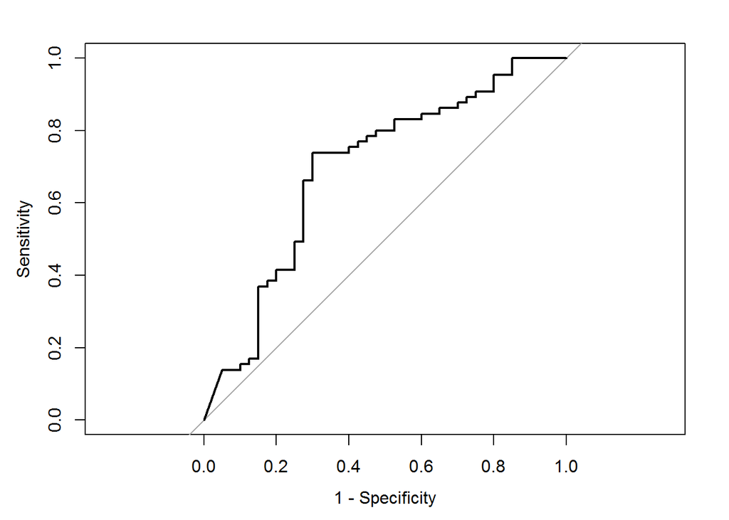

[output not shown]

```r
plot(nb_pre1_10cv_rocCurve, legacy.axes = TRUE)
```

```r
save(nb_pre1_10cv, nb_pre1_10cv_pred, nb_pre1_10cv_prob,
     file = "../Results/nb_pre1_10cv.RData")
```

### nb/PreProc2/10-foldCV

```r
then <- Sys.time()
set.seed(477)
nb_pre2_10cv <- train(x = train_data_sig[, -c(1:2)],
               y = train_data_sig[, "stage"],
               method = "nb",
               ntree = 1000,
               tuneGrid = data.frame(usekernel = c(TRUE, FALSE), fL = 2),
               preProc = c("center", "scale", "pca"),
               importance = TRUE,
               metric = "ROC",
               trControl = ctrl10f)
Sys.time() - then
```

```
## Time difference of 20.5454 secs
```

```r
nb_pre2_10cv_pred <- predict(nb_pre2_10cv,
                            newdata = test_data_sig[, - c(1:2)])
nb_pre2_10cv_prob <- predict(nb_pre2_10cv,
                            newdata = test_data_sig[, - c(1:2)],
                            type = "prob")

nb_pre2_10cv.df <- data.frame(stage = test_data_sig[, "stage"],
                             nb_pre2_10cv_pred,
                             early_prob = nb_pre2_10cv_prob$early,
                             late_prob = nb_pre2_10cv_prob$late)

head(nb_pre2_10cv.df)
```

```
##   stage nb_pre2_10cv_pred early_prob    late_prob
## 1 early             early  0.9989512 0.0010488276
## 2 early             early  0.8834962 0.1165037761
## 3 early             early  0.9997455 0.0002545083
## 4 early             early  0.7958403 0.2041597150
## 5 early             early  0.8731985 0.1268015222
## 6 early             early  0.9781878 0.0218122298
```

```r
confusionMatrix(data = nb_pre2_10cv.df$nb_pre2_10cv_pred,
                reference = test_data_sig[, "stage"],
                positive = "late")
```

```
## Confusion Matrix and Statistics
##
##           Reference
## Prediction early late
##      early    51   26
##      late     14   15
##
##                Accuracy : 0.6226
##                  95% CI : (0.5233, 0.715)
##     No Information Rate : 0.6132
##     P-Value [Acc > NIR] : 0.46329
##
##                   Kappa : 0.1591
##  Mcnemar's Test P-Value : 0.08199
##
##             Sensitivity : 0.3659
##             Specificity : 0.7846
##          Pos Pred Value : 0.5172
##          Neg Pred Value : 0.6623
##              Prevalence : 0.3868
##          Detection Rate : 0.1415
##    Detection Prevalence : 0.2736
##       Balanced Accuracy : 0.5752
##
##        'Positive' Class : late
##
```

```r
nb_pre2_10cv_rocCurve <- roc(response = test_data_sig[, "stage"],
                predictor = nb_pre2_10cv.df$early_prob,
                ## This function assumes that the second
                ## class is the event of interest, so we
                ## reverse the labels
                levels = rev(levels(test_data_sig[, "stage"])))

auc(nb_pre2_10cv_rocCurve)
```

```
## Area under the curve: 0.6081
```

```r
ci.roc(nb_pre2_10cv_rocCurve)
```

```
## 95% CI: 0.4985-0.7177 (DeLong)
```

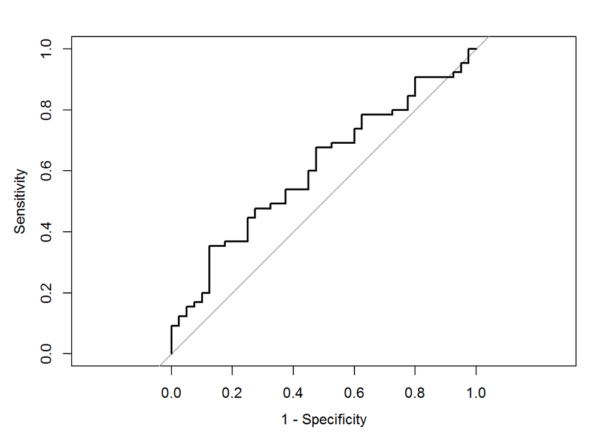

[output not shown]

```r
plot(nb_pre2_10cv_rocCurve, legacy.axes = TRUE)
```

```r
save(nb_pre2_10cv, nb_pre2_10cv_pred, nb_pre2_10cv_prob,
     file = "../Results/nb_pre2_10cv.RData")
```